# **Introduction**

> I'm doing a data analysis, visualization and machine learning model exercise with the gym member dataset. I thought it would be fun to see if it were feasible to try and predict a member's BMI Category (Underweight, Healthy, Overweight, Obese) with the given data. Because I want technical ***and*** non-technical viewers to understand my process, I will be explaining and annotating what I'm doing.

> I'm also playing around with termcolor in this notebook so please bear with it lol.

## **About the Data**

This dataset provides a detailed overview of gym members' exercise routines, physical attributes, and fitness metrics. It contains 973 samples of gym data, including key performance indicators such as heart rate, calories burned, and workout duration. Each entry also includes demographic data and experience levels, allowing for comprehensive analysis of fitness patterns, athlete progression, and health trends.

Key Features:

> Age: Age of the gym member.

> Gender: Gender of the gym member (Male or Female).

> Weight (kg): Member’s weight in kilograms.

> Height (m): Member’s height in meters.

> Max_BPM: Maximum heart rate (beats per minute) during workout sessions.

> Avg_BPM: Average heart rate during workout sessions.

> Resting_BPM: Heart rate at rest before workout.

> Session_Duration (hours): Duration of each workout session in hours.

> Calories_Burned: Total calories burned during each session.

> Workout_Type: Type of workout performed (e.g., Cardio, Strength, Yoga, HIIT).

> Fat_Percentage: Body fat percentage of the member.

> Water_Intake (liters): Daily water intake during workouts.

> Workout_Frequency (days/week): Number of workout sessions per week.

> Experience_Level: Level of experience, from beginner (1) to expert (3).

> BMI: Body Mass Index, calculated from height and weight.

# **Import Libaries and Data**

```
You're good to begin!
```

[figure not shown]

```python
#Reading data
!pip install plotly --upgrade
!pip install termcolor
!pip install catboost
!pip install xgboost

import pandas as pd
import matplotlib

#Fixings warnings
import warnings
warnings.filterwarnings('ignore')

#For mathematical operations
import numpy as np

#Visualisation
import seaborn as sns
import termcolor
import plotly
import plotly.express as px
from termcolor import colored
import matplotlib.pyplot as plt
import plotly.graph_objects as go
import plotly.figure_factory as ff
import plotly.io as pio
from plotly.offline import init_notebook_mode
init_notebook_mode(connected=True)

#Machine Learning libraries
from sklearn.model_selection import train_test_split, GridSearchCV
from sklearn.preprocessing import StandardScaler, MinMaxScaler, LabelEncoder
from sklearn.metrics import accuracy_score, classification_report, mean_squared_error, confusion_matrix

#Models (examples, feel free to add/remove based on needs)
from sklearn.linear_model import LogisticRegression
from sklearn.ensemble import RandomForestClassifier, GradientBoostingClassifier
from sklearn.svm import SVC
from sklearn.tree import DecisionTreeClassifier
from catboost import CatBoostClassifier, CatBoostRegressor
from xgboost import XGBClassifier, XGBRegressor

#Pizzaz
from PIL import Image
from IPython.display import display
thumbs_up_path = "89.png"
thumbs_up = Image.open(thumbs_up_path)
print("You're good to begin!")
display(thumbs_up)
```

```python
df = pd.read_csv('gym_members_exercise_tracking.csv') #I like to name my primary dataframe as df for easier typing and my memory.
```

```python
#Check if the csv converted correctly.
df.head()
```

|  | Age | Gender | Weight (kg) | Height (m) | Max_BPM | Avg_BPM | Resting_BPM | Session_Duration (hours) | Calories_Burned | Workout_Type | Fat_Percentage | Water_Intake (liters) | Workout_Frequency (days/week) | Experience_Level | BMI |
| --- | --- | --- | --- | --- | --- | --- | --- | --- | --- | --- | --- | --- | --- | --- | --- |
| 0 | 56 | Male | 88.3 | 1.71 | 180 | 157 | 60 | 1.69 | 1313.0 | Yoga | 12.6 | 3.5 | 4 | 3 | 30.20 |
| 1 | 46 | Female | 74.9 | 1.53 | 179 | 151 | 66 | 1.30 | 883.0 | HIIT | 33.9 | 2.1 | 4 | 2 | 32.00 |
| 2 | 32 | Female | 68.1 | 1.66 | 167 | 122 | 54 | 1.11 | 677.0 | Cardio | 33.4 | 2.3 | 4 | 2 | 24.71 |
| 3 | 25 | Male | 53.2 | 1.70 | 190 | 164 | 56 | 0.59 | 532.0 | Strength | 28.8 | 2.1 | 3 | 1 | 18.41 |
| 4 | 38 | Male | 46.1 | 1.79 | 188 | 158 | 68 | 0.64 | 556.0 | Strength | 29.2 | 2.8 | 3 | 1 | 14.39 |

# **Data Pre-Processing**

```python
#I'm in America and it's much easier for me to understand weight and height in imperial metrics.

#Covert kg numbers to lb equivalent.
df['Weight (kg)'] = (df['Weight (kg)'] * 2.20462).round(2)  # Convert weight to pounds

#Convert meters to inches.
df['Height (m)'] = (df['Height (m)'] * 39.3701).round(2)  # Convert height to inches

#Rename the columns
df = df.rename(columns={
    'Weight (kg)': 'Weight (lb)',
    'Height (m)': 'Height (in)'
})
#Check my work
df.head(1)
```

|  | Age | Gender | Weight (lb) | Height (in) | Max_BPM | Avg_BPM | Resting_BPM | Session_Duration (hours) | Calories_Burned | Workout_Type | Fat_Percentage | Water_Intake (liters) | Workout_Frequency (days/week) | Experience_Level | BMI |
| --- | --- | --- | --- | --- | --- | --- | --- | --- | --- | --- | --- | --- | --- | --- | --- |
| 0 | 56 | Male | 194.67 | 67.32 | 180 | 157 | 60 | 1.69 | 1313.0 | Yoga | 12.6 | 3.5 | 4 | 3 | 30.2 |

```python
#I need to know how much data I'm working with.

dimension = colored(df.shape, 'green', attrs=['blink'])
print('The dimensions of this dataset are: ', dimension)
```

```
The dimensions of this dataset are:  (973, 15)
```

```python
#Understanding what type of data is in each column, as well as if there are any missing values.
df.info()
```

```
<class 'pandas.core.frame.DataFrame'>
RangeIndex: 973 entries, 0 to 972
Data columns (total 15 columns):
 #   Column                         Non-Null Count  Dtype
---  ------                         --------------  -----
 0   Age                            973 non-null    int64
 1   Gender                         973 non-null    object
 2   Weight (lb)                    973 non-null    float64
 3   Height (in)                    973 non-null    float64
 4   Max_BPM                        973 non-null    int64
 5   Avg_BPM                        973 non-null    int64
 6   Resting_BPM                    973 non-null    int64
 7   Session_Duration (hours)       973 non-null    float64
 8   Calories_Burned                973 non-null    float64
 9   Workout_Type                   973 non-null    object
 10  Fat_Percentage                 973 non-null    float64
 11  Water_Intake (liters)          973 non-null    float64
 12  Workout_Frequency (days/week)  973 non-null    int64
 13  Experience_Level               973 non-null    int64
 14  BMI                            973 non-null    float64
dtypes: float64(7), int64(6), object(2)
memory usage: 114.2+ KB
```

There are no null values in the dataset.

```python
#I'm not going to go overly in-depth in this analysis as the data isn't very complex. But I do want to see if there are significant outliers.

df.describe().style.background_gradient(cmap='YlGn')
```

|  | Age | Weight (lb) | Height (in) | Max_BPM | Avg_BPM | Resting_BPM | Session_Duration (hours) | Calories_Burned | Fat_Percentage | Water_Intake (liters) | Workout_Frequency (days/week) | Experience_Level | BMI |
| --- | --- | --- | --- | --- | --- | --- | --- | --- | --- | --- | --- | --- | --- |
| count | 973.000000 | 973.000000 | 973.000000 | 973.000000 | 973.000000 | 973.000000 | 973.000000 | 973.000000 | 973.000000 | 973.000000 | 973.000000 | 973.000000 | 973.000000 |
| mean | 38.683453 | 162.821429 | 67.818232 | 179.883864 | 143.766701 | 62.223022 | 1.256423 | 905.422405 | 24.976773 | 2.626619 | 3.321686 | 1.809866 | 24.912127 |
| std | 12.180928 | 46.754457 | 5.028450 | 11.525686 | 14.345101 | 7.327060 | 0.343033 | 272.641516 | 6.259419 | 0.600172 | 0.913047 | 0.739693 | 6.660879 |
| min | 18.000000 | 88.180000 | 59.060000 | 160.000000 | 120.000000 | 50.000000 | 0.500000 | 303.000000 | 10.000000 | 1.500000 | 2.000000 | 1.000000 | 12.320000 |
| 25% | 28.000000 | 128.090000 | 63.780000 | 170.000000 | 131.000000 | 56.000000 | 1.040000 | 720.000000 | 21.300000 | 2.200000 | 3.000000 | 1.000000 | 20.110000 |
| 50% | 40.000000 | 154.320000 | 67.320000 | 180.000000 | 143.000000 | 62.000000 | 1.260000 | 893.000000 | 26.200000 | 2.600000 | 3.000000 | 2.000000 | 24.160000 |
| 75% | 49.000000 | 189.600000 | 70.870000 | 190.000000 | 156.000000 | 68.000000 | 1.460000 | 1076.000000 | 29.300000 | 3.100000 | 4.000000 | 2.000000 | 28.560000 |
| max | 59.000000 | 286.380000 | 78.740000 | 199.000000 | 169.000000 | 74.000000 | 2.000000 | 1783.000000 | 35.000000 | 3.700000 | 5.000000 | 3.000000 | 49.840000 |

**Observations**

> **Low Impact**: Most columns (e.g., Weight, Height, Fat Percentage) have values distributed reasonably within the 3-std range, suggesting minimal skewing from outliers.

> **Potential Skew**:

BMI and Calories Burned have potential high-value outliers that could skew the mean. However, the BMI outliers are on the high end and I plan to bin these values together in the categories. The Calories Burned individuals may just be exceptionally fit and shouldn't skew the data much at all.

# Exploratory Data Analysis

#### (Main focus = BMI Categories)

```python
number_of_values=colored(df.nunique(), "green",None, attrs=["blink"])
print(number_of_values)
```

```
Age                               42
Gender                             2
Weight (lb)                      532
Height (in)                       51
Max_BPM                           40
Avg_BPM                           50
Resting_BPM                       25
Session_Duration (hours)         147
Calories_Burned                  621
Workout_Type                       4
Fat_Percentage                   239
Water_Intake (liters)             23
Workout_Frequency (days/week)      4
Experience_Level                   3
BMI                              771
dtype: int64
```

**Next step:** Bin and label the BMI categories.

```python
#I'm using real-world metrics for the BMI categories. Once the first class of Obese is defined, it's just Obese from there.

#Define bins and labels based on real-world BMI categories.
bins = [0, 18.4, 24.9, 29.9, float('inf')]
labels = [
    "Underweight",
    "Healthy",
    "Overweight",
    "Obese"
]

#Apply the classification directly to the BMI column.
df['BMI_Category'] = pd.cut(df['BMI'], bins=bins, labels=labels)

#Define numerical values for each BMI category (important for functions that only work with numerical values)
category_to_value = {
    "Underweight": 1,
    "Healthy": 2,
    "Overweight": 3,
    "Obese": 4
}

#Map numerical values to BMI categories
df['BMI_Category_Value'] = df['BMI_Category'].map(category_to_value)

#Check my work
display(df.head(5))
```

|  | Age | Gender | Weight (lb) | Height (in) | Max_BPM | Avg_BPM | Resting_BPM | Session_Duration (hours) | Calories_Burned | Workout_Type | Fat_Percentage | Water_Intake (liters) | Workout_Frequency (days/week) | Experience_Level | BMI | BMI_Category | BMI_Category_Value |
| --- | --- | --- | --- | --- | --- | --- | --- | --- | --- | --- | --- | --- | --- | --- | --- | --- | --- |
| 0 | 56 | Male | 194.67 | 67.32 | 180 | 157 | 60 | 1.69 | 1313.0 | Yoga | 12.6 | 3.5 | 4 | 3 | 30.20 | Obese | 4 |
| 1 | 46 | Female | 165.13 | 60.24 | 179 | 151 | 66 | 1.30 | 883.0 | HIIT | 33.9 | 2.1 | 4 | 2 | 32.00 | Obese | 4 |
| 2 | 32 | Female | 150.13 | 65.35 | 167 | 122 | 54 | 1.11 | 677.0 | Cardio | 33.4 | 2.3 | 4 | 2 | 24.71 | Healthy | 2 |
| 3 | 25 | Male | 117.29 | 66.93 | 190 | 164 | 56 | 0.59 | 532.0 | Strength | 28.8 | 2.1 | 3 | 1 | 18.41 | Healthy | 2 |
| 4 | 38 | Male | 101.63 | 70.47 | 188 | 158 | 68 | 0.64 | 556.0 | Strength | 29.2 | 2.8 | 3 | 1 | 14.39 | Underweight | 1 |

```python
classes=colored(df['BMI_Category'].unique(), "green",None, attrs=["blink"])
print('The outputs from the classification are :', classes)
```

```
The outputs from the classification are : ['Obese', 'Healthy', 'Underweight', 'Overweight']
Categories (4, object): ['Underweight' < 'Healthy' < 'Overweight' < 'Obese']
```

```python
#I want to see the distribution of BMI categories.
df.groupby('BMI_Category')['BMI_Category_Value'].count()
```

```
BMI_Category
Underweight    163
Healthy        371
Overweight     242
Obese          197
Name: BMI_Category_Value, dtype: int64
```

```python
#Count occurrences of each BMI category and aggregate the data so I can plot it.
#Focusing on using plotly when it makes sense because it just looks better.
bmi_counts = df['BMI_Category'].value_counts().reset_index()
bmi_counts.columns = ['BMI_Category', 'Count']

#Histogram w/ plotly
fig = px.histogram(
    df,
    x='BMI_Category',
    barmode="group",
    color='BMI_Category',
    color_discrete_sequence=['#a5d6a7', '#66bb6a', '#2e7d32', '#0a290a'],
    text_auto=True
)
fig.update_layout(
    title='Distribution of BMI Categories Among Gym-Goers',
    title_font={'size': 25},
    xaxis_title="BMI Category",
    yaxis_title="Number of Gym-Goers",
    plot_bgcolor="#f5f5e8",
    showlegend=False
)
fig.update_yaxes(showgrid=False)
fig.show()

#Pie chart w/plotly
fig = go.Figure(data=[
    go.Pie(
        labels=bmi_counts['BMI_Category'],  # Extracting BMI categories
        values=bmi_counts['Count'],  # Extracting counts
        marker=dict(colors=['#a5d6a7', '#66bb6a', '#2e7d32', '#0a290a'])  # Custom colors
    )
])
fig.update_layout(
    title_text="Distribution of BMI Categories Among Gym-Goers (Pie Chart)"
)
fig.show()
```

[interactive chart not shown]

```python
#Viewing how the numbers between males and females differ.
Gender=colored(df['Gender'].unique(), "green",None, attrs=["blink"])
print('The values of Gender column are :',Gender)
print(df['Gender'].value_counts())
```

```
The values of Gender column are : ['Male' 'Female']
Gender
Male      511
Female    462
Name: count, dtype: int64
```

```python
display(df.groupby('BMI_Category')['Gender'].value_counts())
```

```
BMI_Category  Gender
Underweight   Female     90
              Male       73
Healthy       Female    222
              Male      149
Overweight    Female    125
              Male      117
Obese         Male      172
              Female     25
Name: count, dtype: int64
```

At first glance, I see some big differences.

```python
#Code for the Pie Charts
#Group data by Gender
gender_groups = df.groupby('Gender')

#Define color mapping for BMI categories (I like green)
color_map = {
    'Healthy': '#a5d6a7',
    'Underweight': '#66bb6a',
    'Overweight': '#2e7d32',
    'Obese': '#0a290a'
}

#Create a list to hold subplot pie charts
fig = go.Figure()

#Looping through each gender group to create each chart saved a lot of time
for idx, (category, group) in enumerate(gender_groups):
    #Count the distribution of BMI_Category within this Gender
    BMI_counts = group['BMI_Category'].value_counts()

    #Map the colors to the BMI_Category order in BMI_counts
    colors = [color_map[label] for label in BMI_counts.index]

    #Add a pie chart for the current gender group
    fig.add_trace(go.Pie(
        labels=BMI_counts.index,
        values=BMI_counts.values,
        marker=dict(colors=colors),
        textinfo='percent+label',
        domain=dict(
            row=0,
            column=idx
        ),
        name=f"{category}"  #Add a legend
    ))

#Update the layout to arrange pie charts side-by-side
fig.update_layout(
    title="Distribution of BMI Categories by Gender",
    grid=dict(rows=1, columns=len(gender_groups)),
    annotations=[dict(
        text=f'{category}',
        x=0.2 if idx == 0 else 0.8,  #Annotations above the charts
        y=1.15,
        font=dict(size=14),
        showarrow=False
    ) for idx, (category, group) in enumerate(gender_groups)]
)

fig.show()
```

[interactive chart not shown]

**Observations**

**Healthier BMI Distribution in Females:**

> **Females** have a significantly larger proportion in the **Healthy** BMI category compared to males.

**Higher Obesity in Males:**

> **Males** exhibit a disproportionately high **obesity** rate.

**Next Step:** See if workout types affect BMI.

```python
#Checking to see if workout types affect BMI. The process is basically the same as the last group of pie charts.
color_map = {
    'Yoga': '#a5d6a7',
    'Cardio': '#66bb6a',
    'Strength': '#2e7d32',
    'HIIT': '#0a290a'
}

#Group
bmi_groups = df.groupby('BMI_Category')

#Create a figure
fig = go.Figure()

rows = 2
columns = 2

#Track the annotations (I initially had a lot of trouble with the annotations and this was my solution to keep them consistent).
annotations = []

#Loop through each BMI category and create a pie chart
for idx, (category, group) in enumerate(bmi_groups):

    workout_counts = group['Workout_Type'].value_counts()


    colors = [color_map[label] for label in workout_counts.index]

    #Adjust domain to position the pie charts in a grid
    domain_x_start = (idx % columns) / columns + 0.05
    domain_x_end = domain_x_start + 0.4
    domain_y_start = 1 - (idx // columns + 1) / rows + 0.05
    domain_y_end = domain_y_start + 0.4

    #Add a pie chart for the current BMI category
    fig.add_trace(go.Pie(
        labels=workout_counts.index,
        values=workout_counts.values,
        marker=dict(colors=colors),
        textinfo='percent+label',
        name=f"{category}",  #For the Legend
        domain=dict(
            x=[domain_x_start, domain_x_end],
            y=[domain_y_start, domain_y_end]
        )
    ))

    #Add annotations
    x_pos = (domain_x_start + domain_x_end) / 2
    y_pos = domain_y_end + 0.035
    annotations.append(dict(
        text=f'{category}',
        x=x_pos,
        y=y_pos,
        font=dict(size=16, color="black"),
        showarrow=False,
        xanchor="center",
        yanchor="bottom"
    ))

fig.update_layout(
    title="Distribution of Workout Types by BMI Category",
    width=1000,
    height=800,
    showlegend=True,
    annotations=annotations  #Add annotations to the layout
)

fig.show()
```

[interactive chart not shown]

**Observations**

> **Strength Dominance:**

Strength training is the top choice for the **Underweight** and **Overweight** groups, reflecting a focus on building muscle and managing weight.

> **Cardio Preference:**

The **Healthy** and **Obese** groups favor Cardio exercises, aligning with its cardiovascular and weight-loss benefits.

> **Balanced Choices in Healthy Group:**

The **Healthy** group shows a balanced preference for all workout types, reflecting diverse fitness goals.

> **Lower Preference for HIIT:**

Across all BMI categories, **HIIT** tends to be less popular, likely due to its high intensity and physical demands.

**Next Step:** Assess correlations.

```python
#.corr() only works with numerical values. So for each catergory that was non-numeric, they received a sister numerical column.

#Add numerical sister column for Gender
gender_mapping = {'Male': 1, 'Female': 0}
df['Gender_Value'] = df['Gender'].map(gender_mapping)

#Add numerical sister column for Workout_Type
workout_mapping = {'Yoga': 1, 'Cardio': 2, 'Strength': 3, 'HIIT': 4}
df['Workout_Value'] = df['Workout_Type'].map(workout_mapping)

# Drop non-numerical columns to focus on numerical correlations
numerical_df = df.drop(['Gender', 'Workout_Type', 'BMI_Category'], axis=1)

# Calculate the full correlation matrix
correlation_matrix = numerical_df.corr()

#I got some sort of duplication error so there's active debugging in the next two lines

#Extract correlations for 'BMI_Category_Value'
correlation_with_attribute = correlation_matrix[['BMI_Category_Value']].copy()  #Debug
correlation_with_attribute.reset_index(inplace=True)
#Rename columns to avoid duplication
correlation_with_attribute.columns = ['Attribute', 'BMI_Correlation'] #Debug

#I want to easily read the most correlation to the least correlation
correlation_with_attribute = correlation_with_attribute.sort_values(by='BMI_Correlation', ascending=False)

#Check the scores
genders=colored(gender_mapping, "green",attrs=["blink"])
workouts=colored(workout_mapping, "green", attrs=["blink"])
print("Males and Females are represented by: ", genders)
print("The different types of workouts are represented by: ", workouts)
print(correlation_with_attribute)
```

```
Males and Females are represented by:  {'Male': 1, 'Female': 0}
The different types of workouts are represented by:  {'Yoga': 1, 'Cardio': 2, 'Strength': 3, 'HIIT': 4}
                        Attribute  BMI_Correlation
13             BMI_Category_Value         1.000000
12                            BMI         0.917591
1                     Weight (lb)         0.794619
14                   Gender_Value         0.288770
9           Water_Intake (liters)         0.215626
7                 Calories_Burned         0.076578
3                         Max_BPM         0.065367
11               Experience_Level         0.032044
15                  Workout_Value         0.016913
6        Session_Duration (hours)         0.015914
4                         Avg_BPM         0.014363
10  Workout_Frequency (days/week)        -0.001310
0                             Age        -0.017333
5                     Resting_BPM        -0.045068
8                  Fat_Percentage        -0.122308
2                     Height (in)        -0.140081
```

**Observation and a Key Decision**

**Using BMI to predict the category feels like cheating:**

> The correlation values from **Weight** to **Water Intake** seem to be the most impactful. After that, the drop off is significant. However, I feel that using at least **6-7 features** should give enough data for the models to work with. Using the **actual BMI** numeric values is a bit ***too on-the-nose*** so I will not use that feature for the models.

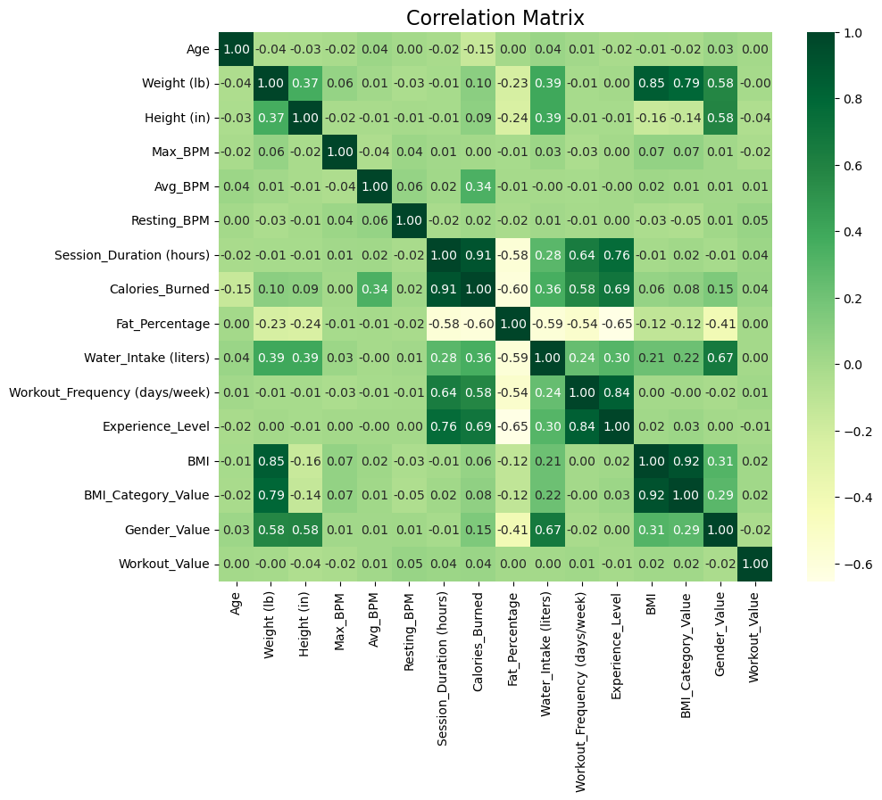

```python
#Correlation Matrix Code
plt.figure(figsize=(10, 8))

sns.heatmap(correlation_matrix, annot=True, cmap='YlGn', fmt='.2f')

plt.title('Correlation Matrix', fontsize=16)

plt.show()
```

**Next Step:** Observe correlation and distribution against BMI for the machine learning features.

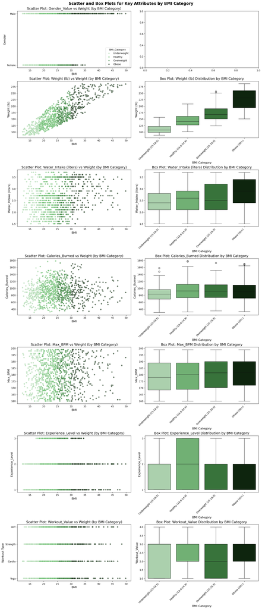

```python
#Show scatter and box plots for the features I chose for the ML models.
#Apply consistent BMI_Category order so the graphs move from smallest to largest.
bmi_order = ['Underweight', 'Healthy', 'Overweight', 'Obese']
df['BMI_Category'] = pd.Categorical(df['BMI_Category'], categories=bmi_order, ordered=True)

#Attributes to analyze
attributes_to_plot = ['Gender_Value', 'Weight (lb)', 'Water_Intake (liters)', 'Calories_Burned', 'Max_BPM', 'Experience_Level', 'Workout_Value']

#Mapping of BMI categories to ranges
bmi_ranges = {
    'Underweight': '15-18.5',
    'Healthy': '18.6-24.9',
    'Overweight': '25-29.9',
    'Obese': '30+'
}

#Define a consistent color palette for BMI categories
palette = ['#a5d6a7', '#66bb6a', '#2e7d32', '#0a290a'] #I like green

#Set up the figure for subplots
num_attributes = len(attributes_to_plot)
fig, axes = plt.subplots(num_attributes, 2, figsize=(15, 5 * num_attributes), constrained_layout=True)
axes = axes.flatten()

# Loop through attributes to create scatter and box plots
for i, attribute in enumerate(attributes_to_plot):

    #Scatter Plots
    sns.scatterplot(
        data=df, x='BMI', y=attribute, hue='BMI_Category',
        ax=axes[2 * i], palette=palette, alpha=0.6, legend=(i == 0)  # Show legend only on the first plot
    )
    axes[2 * i].set_title(f'Scatter Plot: {attribute} vs Weight (by BMI Category)', fontsize=14)
    axes[2 * i].set_xlabel('BMI', fontsize=12)
    axes[2 * i].set_ylabel(attribute, fontsize=12)

    #Skip the Gender_Value box plot
    if attribute == 'Gender_Value':
        continue

    #Box Plots
    sns.boxplot(
        data=df, x='BMI_Category', y=attribute, ax=axes[2 * i + 1], palette=palette, order=bmi_order
    )
    axes[2 * i + 1].set_title(f'Box Plot: {attribute} Distribution by BMI Category', fontsize=14)
    axes[2 * i + 1].set_xlabel('BMI Category', fontsize=12)
    axes[2 * i + 1].set_ylabel(attribute, fontsize=12)

    #Add custom BMI category labels with ranges to the x-axis
    updated_labels = [f"{cat} ({bmi_ranges[cat]})" for cat in bmi_order]
    axes[2 * i + 1].set_xticklabels(updated_labels, rotation=45, ha='right')

    #Modify the x-axis for specific charts
    axes[-2].set_yticks([1, 2, 3, 4])
    axes[-2].set_yticklabels(['Yoga','Cardio','Strength','HIIT'], fontsize=10)
    axes[-2].set_ylabel("Workout Type")
    axes[-4].set_yticks([1, 2, 3])
    axes[-3].set_yticks([1, 2, 3])
    axes[-14].set_yticks([0, 1])
    axes[-14].set_yticklabels(["Female", "Male"])
    axes[-14].set_ylabel("Gender")

# Add a main title for the entire figure
fig.suptitle('Scatter and Box Plots for Key Attributes by BMI Category', fontsize=16, fontweight='bold')

#Show my work
plt.show()
```

**Observations**

**Gender**

> **Females** generally fall in lower BMI ranges compared to males, with **fewer outliers** in the **obese** category.

**Weight and Calories Burned:**

> **Healthy** individuals display a wide variation in calories burned, possibly reflecting diverse activity intensities.

**Water Intake:**

> **Water intake** is fairly consistent across BMI categories but slightly higher for **obese** individuals.

**Max BPM:**

> **Max BPM** does not strongly correlate with BMI, indicating it depends more on fitness level and effort.

**Workout Type:**

**Experience Level:**

> **Healthy** BMI individuals tend to have the highest experience levels in fitness activities.

# **Machine Learning**

#### I will be traing Logistic Regression, Random Forest, XGBoost, CatBoost, SVC, and GradientBoosting models. I will tune and evaluate them for the best recommendation.

## **Base Model Performance**

```python
#Base Model Code
#Features and target
features = ['Gender_Value', 'Weight (lb)', 'Water_Intake (liters)', 'Calories_Burned', 'Max_BPM', 'Experience_Level', 'Workout_Value']
target = 'BMI_Category_Value'  # Replace with the actual target column name

#Split the data
X = df[features]
y = df[target]

#Convert categorical target values to numeric label (This is a debug for me.)
if y.dtype.name == 'BMI_Category_Value':  # Check if the column is categorical
    y = y.cat.codes  # Convert directly if it's a pandas Categorical
else:
    le = LabelEncoder()  # Use sklearn LabelEncoder if it's a generic object dtype
    y = le.fit_transform(y)

#Adjust the target labels to start from 0 for XGB (another debug)
y = y - y.min()

#Split the data
X_train, X_test, y_train, y_test = train_test_split(X, y, test_size=0.2, random_state=42)

#Training the base model seems to work the same for these models so I will just loop the process to save time.
models = {
    "Logistic Regression": LogisticRegression(random_state=42),
    "Random Forest": RandomForestClassifier(random_state=42),
    "XGBoost": XGBClassifier(random_state=42, use_label_encoder=False, eval_metric='logloss'),
    "CatBoost": CatBoostClassifier(verbose=0, random_state=42),
    "SVC": SVC(random_state=42, probability=True),
    "Gradient Boosting": GradientBoostingClassifier(random_state=42)}

#Train and evaluate models
results = {}

for model_name, model in models.items():
    print(f"Training {model_name}...")

    model.fit(X_train, y_train)

    y_pred = model.predict(X_test)

    accuracy = accuracy_score(y_test, y_pred)
    print("Classification Report:")

    #Store the result (to use later)
    results[model_name] = {
        "model": model,
        "accuracy": accuracy}

    #Calculate training and testing scores
    training_score = colored(round(model.score(X_train, y_train) * 100, 2), "green", None, attrs=["blink"])
    testing_score = colored(round(model.score(X_test, y_test) * 100, 2), "green", None, attrs=["blink"])

    #Print results
    print(f"{model_name} training score :", training_score)
    print(f"{model_name} testing score :", testing_score)
    print("\n" + "-" * 50 + "\n")
```

```
Training Logistic Regression...
Classification Report:
Logistic Regression training score : 58.35
Logistic Regression testing score : 60.51

--------------------------------------------------

Training Random Forest...
Classification Report:
Random Forest training score : 100.0
Random Forest testing score : 58.97

--------------------------------------------------

Training XGBoost...
Classification Report:
XGBoost training score : 100.0
XGBoost testing score : 56.92

--------------------------------------------------

Training CatBoost...
Classification Report:
CatBoost training score : 100.0
CatBoost testing score : 60.0

--------------------------------------------------

Training SVC...
Classification Report:
SVC training score : 51.8
SVC testing score : 42.56

--------------------------------------------------

Training Gradient Boosting...
Classification Report:
Gradient Boosting training score : 90.87
Gradient Boosting testing score : 57.44

--------------------------------------------------
```

```python
#Grouped Bar Chart code
#Store the scores
base_results = {
    "Logistic Regression": {"accuracy": 60.51, "training_score": 58.35},
    "Random Forest": {"accuracy": 58.97, "training_score": 100.0},
    "XGBoost": {"accuracy": 56.92, "training_score": 100.0},
    "CatBoost": {"accuracy": 60.0, "training_score": 100.0},
    "SVC": {"accuracy": 42.56, "training_score": 51.8},
    "Gradient Boosting": {"accuracy": 57.44, "training_score": 90.87},
}

#Extract data
model_names = list(base_results.keys())
training_scores = [base_results[model]["training_score"] for model in model_names]
testing_scores = [base_results[model]["accuracy"] for model in model_names]

#Start making the chart
fig = go.Figure()

#Add Training Scores
fig.add_trace(go.Bar(
    x=model_names,
    y=training_scores,
    name="Training Score",
    marker_color="#a5d6a7",
    text=[f"{score:.2f}" for score in training_scores],  #Add annotations
    textposition="inside"
))

#Add Testing Scores
fig.add_trace(go.Bar(
    x=model_names,
    y=testing_scores,
    name="Testing Score",
    marker_color="#2e7d32",
    text=[f"{score:.2f}" for score in testing_scores],  #Add annotations
    textposition="inside"
))

fig.update_layout(
    title="Model Performance Comparison (Training vs Testing)",
    xaxis_title="Models",
    yaxis_title="Score (%)",
    barmode='group',
    xaxis_tickangle=45,
    yaxis=dict(range=[0, 110]),  #Adjusting range for readability
    legend=dict(title="Legend")
)

fig.show()
```

[interactive chart not shown]

**Observations**

> **Logistic Regression:**

> **Random Forest:**

Perfect training score indicates overfitting. Testing score drops significantly, meaning the model generalizes poorly to unseen data.

> **XGBoost:**

Like Random Forest, XGBoost is overfitting with a perfect training score. Testing score is relatively low, indicating poor generalization.

> **CatBoost:**

Another case of overfitting, with a perfect training score. Testing score is slightly better than Random Forest and XGBoost but still reflects overfitting.

> **SVC (Support Vector Classifier):**

Poor performance in both training and testing. Indicates the model is underfitting, failing to capture the complexity of the data.

> **Gradient Boosting:**

Better balance between training and testing scores compared to Random Forest and XGBoost. Slight overfitting but more generalizable than the other tree-based models.

**Key Observations**

> **Overfitting:**

Random Forest, XGBoost, and CatBoost exhibit overfitting with perfect training scores.

> **Underfitting:**

SVC has low performance in both training and testing, indicating underfitting.

> **Best Balance:**